# Exercise 5: Alien Escape

Emily Simmonds

# Instructions:

This document contains information, questions, R code, and plots.

**Hints and reminders are bold**

Questions appear in blue.

**Needs to be completed and handed in by Friday 4th March 23:59 2022**

This week you will be looking at multiple regression, working out when to use it, practicing how to use it, and interpreting results.

## R hints and general help

### Resources:

- Google (or any other search engine) e.g. “multiple regression in R”
- [Week 7 lectures](https://www.math.ntnu.no/emner/ST2304/2021v/Week07/)

### R this week:

New functions:

- `pairs()` a function to plot all scatterplots of each variable in your data against the others in paired plots. It takes the argument `x`, which is your data object. e.g. `pairs(YOURDATA)`
- `plotting_function()` a function we have created for you to plot your predictions on a map. It takes the arugments: `InputData` and `Predictions`.

Things to remember:

- `lm()` takes the arguments x, y, and data e.g. `lm(y ~ x, data = YOURDATA)` x and y here correspond to an explanatory variable (x) and a response (y)
- `plot()` and `abline()`
- `predict()`
- `confint()` and `coef()`
- `par(mfrow=(NumberRows, NumberColumns))` to make more than one plotting window.
- `summary(YourModel)$r.squared`
- code to make diagnostic plots for model checking e.g. residuals vs fitted, normal Q-Q, and cook’s distance.

## A bit more on the `predict()` function

You have been using the `predict()` function for a few weeks now, so it seemed like a good time to have a quick recap of how the function works.

The main arguments we use for predict are: `object` = YourModelObject, `newdata` = a dataframe of data you want to predict for, and `interval` = either prediction or confidence.

A few comments on the arguments:

- `object`. The model objects you have used to predict with so far have been created using the `lm()` function. You know there are two ways to write an model using `lm()`, `lm(y ~ x, data = YOURDATA)` and `lm(YOURDATA$y ~ YOURDATA$x)`. Some of you might have noticed that if you use predict without a `newdata` argument, it does not matter how you wrote your `lm()`. **But** if you do need to use a `newdata` argument, then predict only works correctly if you wrote your `lm()` like this: `lm(y ~ x, data = YOURDATA)`. This is because the column names in `newdata` need to perfectly match those in the model formula (`y~x`) for predict to work. When you write your formula with a `$` then this is how R sees the variable name e.g. it is YOURDATA$x not x. By splitting out the column names from the data, it makes it clear to R what the variables are called and then it can match those to what you give it in `newdata`.
- `newdata`. This week you will start using `newdata` with more than onecolumn. When you do multiple regression, you have multiple explanatory (x) variables. Therefore, when you predict, you need to include values for all of your x’s, not just one. Many of you have already been creating `newdata` using `<- data.frame(x=ValueYouWantToPredictFor)`, now you will need to include two columns in these dataframes. The `data.frame()` function tells R to create a dataframe, the bits inside the brackets tell it what you want inside. The column name goes on the left, = in the middle, and the values for the column on the right. An example of a two column `newdata` `newdata <- data.frame(x = 1:5, x2 = 6:10)`.
- **Remember the column names in newdata should match your x variable names.**

# The challenge: Will we be taken over by aliens?

It is a time in the near future, space travel has become more common. Ships leave from earth every few months on exploration missions of the galaxy. Ship “Explorer 5” has been searching to see if any life on other planets could be useful on earth. During the mission the crew found a planet with life and collected some organisms. The alien organism 101 is a multicoloured, modular, plant-like organism (the plant-animal divide is less clear for aliens). The organism seems to grow well in air similar to earth’s atmosphere and could be useful as it grows flower-like structures made of gold.

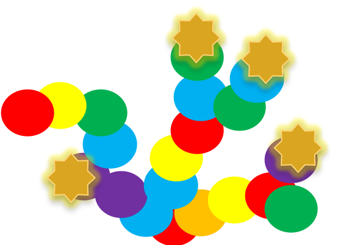

Alien picture

On their way back to earth the scientific crew of “Explorer 5” have been conducting experiments on alien 101 to try and determine the conditions under which it grows best. The scientists grew alien 101 in containers under different temperatures (ºC) and rainfall (mm) conditions. They recorded the weight of biomass (g) of alien 101 per square metre after one week.

Unfortunately, on the journey back, the ship hit a satellite and has crash landed on Australia. The crew were able to survive, but the experimental lab has been badly damaged. Alien 101 has been released into the wild on earth.

You are a local team of scientists assisting the space travel company with predicting how the organism might spread. The company want to know where to focus their containment resources to stop the organism from taking over. Even if it could be useful, they don’t know how it could damage earth’s wildlife.

**It is your job to predict where the alien organism will spread to and recommend how to deploy resources**

The data can be found at https://www.math.ntnu.no/emner/ST2304/2021v/Week07/Alien101LabData.csv

The first step is to import the data and assign it to an object. You can use the whole web link above to import the data. It is a csv file with column names (header) included.

```r
Alien <- read.csv("https://www.math.ntnu.no/emner/ST2304/2021v/Week07/Alien101LabData.csv",
                  header=TRUE)
```

A1. Plot the data using the `pairs()` function. What can you tell from the plots?

A2. Have a look at the raw data from Explorer 5, do you think rainfall and temperature were tested separately in their experiments? Why/why not?

**Hint**

Here you need to look at the raw data i.e. the data frame you have. `head()` is one function you can use to do this. or click on the data object in the Environment panel on the top left.

You need to think about how the way data are collected relates to the way it is presented. For instance, if you tested temperature and rainfall separately, how would you write this into a table? How many columns would you have? What would each row represent?

If you aren’t sure, pretend you are designing the experiment from the beginning and make a draft of the table you would use.

A3. **Run** a simple linear regression for each of i) temperature and biomass, ii) rainfall and biomass. Give the coefficient estimates (of each parameter), the confidence intervals, and say how much variance each model explains.

**Remember to put the explanatory variable and the response in the right places, you might need to think about which is which.**

**I’ve forgotten how to do this!**

use `lm()` for the model, `coef()` to see the estimates, `confint()` to get confidence intervals, and `summary()$r.squared` to see how much variance is explained.

If none of this is familiar - look over the exercises from previous weeks!

A4. **Interpret** the results of the separate linear regressions. What do the results suggest about the ideal conditions for alien 101?

You now have some results about how temperature and rainfall (individually) influence the growth of alien 101. But you want to generate predictions of how it could spread around Australia. You can do this by creating predictions of the amount of biomass for the actual average annual temperature and rainfall of Australia. The company have provided you with very simplified data of the average annual temperature and total annual rainfall for different coordinates in Australia. Found at: https://www.math.ntnu.no/emner/ST2304/2021v/Week07/AustraliaEnvironmentalData.csv

This is plotted below.

Using this you can try to guess where the alien might spread to based on what you have found out about the influence of temperature and rainfall on alien 101’s growth. **Assume that amount of biomass is an indicator of how suitable the conditions are for alien 101.**

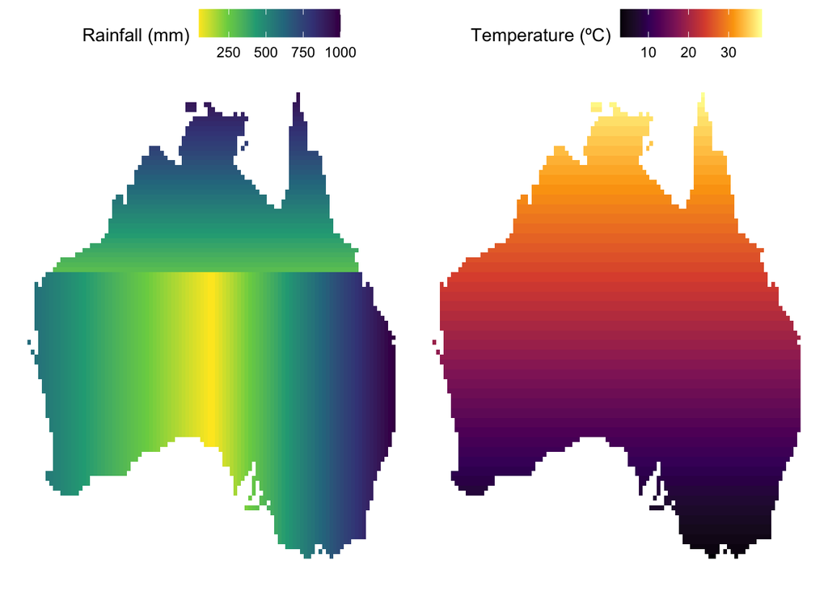

While guessing is ok. It would be better to predict actual numbers based on our linear models. To do this, you will need to:

- Import the Australia environmental data.
- Use the `predict()` function to generate the predictions.

A5. **Predict** biomass of alien 101 across Australia.

To make the predictions you will use the data on environmental conditions in Australia. These will become your new explanatory variable (x) values that you want to predict a response (y) from.

**I need a hint**

You need to create an object to be your `newdata` argument for the predict function. `data.frame()` is a good function to use for this. You will need two because you have two different models, one with temperature and one with rainfall.

Remember that the column names in `newdata` must be the same as those used to make your model.

**If it doesn’t work - check your `lm()` is written as described in the start of this document.**

**Nope, still not sure**

**Make sure to read all comments.** You may need to change the name of the datafile to match what you called the Australia data.

```r
# First thing for the prediction is to create the newdata object
# you will need as an argument for the predict() function.

# Here you need two, one for temperature and one for rainfall.
# Newdata needs to be a datafame so the function data.frame() is very
# useful here. My data is called Australia and my models are ModelTemp
# and ModelRain.
# Column names in newdata MUST be identical to those in the
# data used to make the model (the lab data).

# newdata for temperature (it makes a dataframe with a column called
# Temperature from the Temp column in the Australia data)
newdataTemp <- data.frame(Temperature = Australia$Temp)

# newdata for rainfall
newdataRain <- data.frame(Rainfall = Australia$Rain)

# now predict - this should be familiar now
PredictionsTemp <- predict(ModelTemp, newdata = newdataTemp,
                           interval="prediction")

# now predict - this should be familiar now
PredictionsRain <- predict(ModelRain, newdata = newdataRain,
                           interval="prediction")
```

Now you have predictions for the biomass in g/m<sup>2</sup> for the whole of Australia. If you look at the results, the numbers are very large. This is because biomass is in grams. From looking just at the numbers it is difficult to interpret these predictions.

Another member of your team (Emily) has created a function in R to plot the predicted results back onto the map of Australia. It is quite a complex function and uses the package `ggplot2`. You can google this if you want to learn more but it can make some very pretty plots!

To use the function, first install the following packages using `install.packages()`:

- “ggplot2”
- “viridis”

Then load them using the `library()` function. e.g. `library(ggplot2)`

The plotting function is available here: https://www.math.ntnu.no/emner/ST2304/2021v/Week07/plotting_function.R. You can bring the function into your R by using the `source()` function.

### What does source really do?

The `source()` function is something we can use to run all of the code in an R script. We use this in this course to provide you with functions that we write ourselves. It is a bit like bringing in data, but instead of data, it is R code. Have a go at sourcing the script for this week using `source()` and using the url above as the argument. You should see that in the right hand Environment panel you now have a function called `plotting_function()`, it is ready to use.

A6. Plot your predictions using `plotting_function()`.

**R hint**

```r
# source the script
source("https://www.math.ntnu.no/emner/ST2304/2021v/Week07/plotting_function.R")

plotting_function(InputData = Australia, Predictions = PredictionsRain[,1])

plotting_function(InputData = Australia, Predictions = PredictionsTemp[,1])
```

A7. Based on these results where would you recommend the company focusses its containment resources? Include some mention of uncertainty in your answer.

# Part B: Multiple regression

Your team have made some predictions based on using temperature and rainfall separately. But you know what you can put both variables into a combined multiple regression model. So you now decide to do this.

B1. **Write** a line of R code (and run it) to run a multiple linear regression including temperature **and** rainfall.

If you are not sure how to do this, have a look at question C3 from Exercise 4. In Exercise 4 you added a quadratic term to your model, this was actually creating a type of multiple regression. You add any other explanatory variables in the same way, but without `I` or `^2`.

B2. **Write** the multiple linear regression as a mathematical equation? E.g. Y=…. **Hint: think about how this is different to a simple regression**

B3. **Compare** the estimates from the multiple regression to those from the individual regressions. **Include coefficients, confidence intervals, and R squared**

Remember you can also plot the results. To do this you should plot each variable against biomass separately i.e. biomass against temperature and biomass against rainfall but you will need to adjust the line you are plotting with the mean value of the other variable.

To do this, you can still use `abline()`

```r
# EXAMPLE:

# make two plot window
par(mfrow=c(1,2))

# make the plot of temperature and biomass
plot(Alien$Temperature, Alien$Biomass,
     pch = 19, col = "red",
     ylab = "Biomass", xlab = "Temp")

# save the coefficient values as an object
# contains 3 values, intercept, slope for temperature,
# slope for rainfall
coefs <- coef(ModelBoth)

# use the coefficients to plot the line for temperature
abline(a=coefs[1]+(mean(Alien$Rainfall)*coefs[3]), b=coefs[2], col="black")

# make the plot of Rainfall and biomass
plot(Alien$Rainfall, Alien$Biomass,
     pch = 19, col = "blue",
     ylab = "Biomass", xlab = "Rain")

# save the coefficient values as an object
# contains 3 values, intercept, slope for temperature,
# slope for rainfall
coefs <- coef(ModelBoth)

# use the coefficients to plot the line for temperature
abline(a=coefs[1]+(mean(Alien$Temperature)*coefs[2]), b=coefs[3], col="black")
```

B4. **How** does R find the estimates of the parameters for these linear regressions? **Hint: think back to earlier weeks - its the same**

B5. **Perform** model checking of the multiple linear regression. **Include 3 plots of model checking and decide if you think the fit is ok**

**Hint: code available in Exercise 4**

Now you have checked your model and hopefully are either happy with it or have fixed any assumptions that were violated. So now you can generate new predictions of biomass in Australia based on the multiple regression model. **This is still not the full picture, remember to look at the uncertainty too. You can do this by entering the upper or lower prediction as the `Predictions` argument in `plotting_function()`.** To do this you need to use indexing like last week. The lower confidence interval is column 2 in the output from the `predict()` function e.g.

```r
Predictions <- predict(YOURMODEL, newdata=newdata, interval="prediction")
Predictions[,2] # this bit gives the second column
```

B6. **Predict** where the organism will spread to, based on the multiple regression. Plot it using `plotting_function()`.

**Hint: You can do this by editting the prediction code above so it predicts from the multiple regression. Now you also only need one `newdata` object with two columns.**

**I need help!**

Try editting the code from A5 and A6

Australia = dataset of environmental conditions in Australia.

This shows code to plot the mean predictions. To check how uncertainty changes the patter you can change which column of the object `PredictionsBoth` that you plot.

```r
PredictionsBoth <- predict(ModelBoth, newdata = data.frame(Temperature = Australia$Temp,
                                                           Rainfall = Australia$Rain),
                           interval="prediction")
```

```r
plotting_function(InputData = Australia,
                              Predictions = PredictionsBoth[,1])
```

B7. **What** would you recommend in terms of deployment of resources based on your predicted spread? Has this changed from before?

## Part C: Reflection

C1. Can you draw any biological conclusions about this alien species? Can you say anything about the relative influence of temperature and rainfall? Are the variables in this analysis enough, what else could have an influence?

C2. **Why** do we use multiple regressions rather than running individual simple linear regressions?

## Part D: Feedback

D1. How do you think this exercise went? What do you think your group did well, what are you less sure about? (2 examples of each)

D2. What do you think you improved from last week?

D3. Are there any concepts you are very unsure of?

D4. What would you like feedback on this week?